# Project proposal

Sophie La Gennusa, Özgür Aydemir, Francesco Darino, Louis del Perugia, Daniel Szenes

# 1 Goal Impact

In the scope of this class, we will be working with Nestle through Joao Ramalho.

Our project would be an application on industrial production area. More precisely the final and ambitious objective of the work is to help the Nestle coffee production creating a shiny application to support the controlling mechanism of the coffee weight during the new capsules recipes formulations. Since the coffee is an expensive row material, even a little variation in the quantities, taking account of the massive scale of the production, has an impact on the cost of goods sold of the company; indeed, a control of the weight in that sense could help to optimize such industrial process. The application would be used by different users: The operator, that would use the app to control his work. The project manager, to check the big picture of the project in the R&D branch of the company.

# 2 Plan

We would start from scratch, from an empty page, to create a shiny application using some necessary packages: such as “shiny”, “shinydashboard” for the construction of the application and some other packages to create a dataset visual (such as “DT”), moreover we implement some fancy “ggplot” graphs to facilitate visualizations, applying some filters on the data and useful tools to let operators take records in an efficient ways of the quantities. We have about 1 year data with thousands of observations and some variables about the operator, the request numbers, the date, the target weights, and the confidence intervals. The main source of ispiration of the project is the meeting with Joao Ramalho that explained us his project idea.

# 3 Timeline

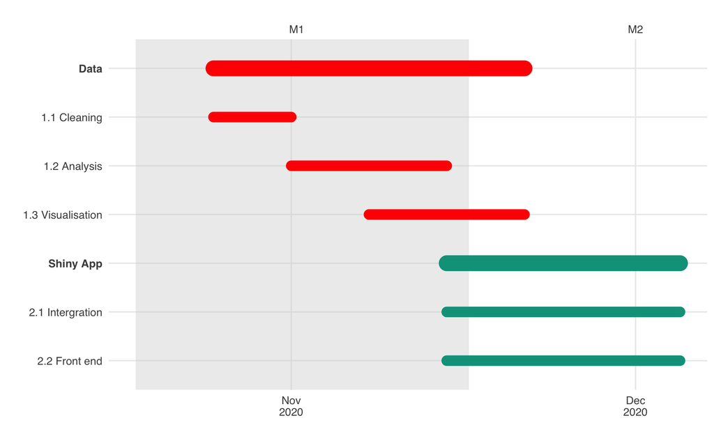

# 4 Management Plan

For the organisation of our project, we want to create 2 group within us to split the tasks.

One group will be responsable of the management of “Data Cleaning and Wrangling” and the other group will be responsible of the creation of the “Shiny App” for a better visualization.

We plan to make weekly zoom or meet in the campus every Friday afternoon to discuss between each other the next steps to follow and analyze everyone’s work.

| Sophie | Louis | Francesco | Daniel | Özgür |
| --- | --- | --- | --- | --- |
| Data Cleaning/Wrangling | Data Cleaning/Wrangling | Shiny App Integration | Data Cleaning/Wrangling | Shiny App Integration |